# Introduction to the CICCplot function

Ann-Sophie Buchardt

Karl Bang Christensen

Sidsel Normann Jensen

August 14, 2023

## Introduction

This vignette describes how one can use the `CICCplot` function to compute and visualise conditional item characteristic curves (CICCs).

First, we load the `RASCHplot` package

```r
library(RASCHplot)
```

The functions in the package are applicable on polytomous as well as dichotomous items. We load the polytomous SPADI data set from the package. Users can either load their own data or use those saved in the workspace.

```r
data(SPADI)
```

The command loads data from this saved R data archive. Data are from a Danish validation study containing responses to the shoulder pain and disability index (SPADI) from 228 patients with rotator-cuff related disorders.

```r
str(SPADI)
```

```
'data.frame':   228 obs. of  16 variables:
 $ gender: int  1 1 1 1 1 1 1 2 2 2 ...
 $ over60: int  1 0 0 0 0 0 0 1 1 1 ...
 $ id    : int  1 2 3 4 5 6 7 8 9 10 ...
 $ P1    : int  3 3 5 3 4 5 3 5 4 4 ...
 $ P2    : int  3 1 2 3 5 4 3 4 4 4 ...
 $ P3    : int  4 3 3 3 5 4 3 5 4 4 ...
 $ P4    : int  3 3 1 2 3 2 3 4 4 4 ...
 $ P5    : int  4 1 2 0 0 4 2 3 1 3 ...
 $ D1    : int  2 2 0 0 3 3 0 4 4 3 ...
 $ D2    : int  1 3 1 4 3 5 1 5 5 4 ...
 $ D3    : int  2 3 1 0 2 3 0 4 4 2 ...
 $ D4    : int  1 3 0 0 2 1 0 1 0 2 ...
 $ D5    : int  1 3 0 0 0 0 0 2 0 3 ...
 $ D6    : int  4 3 1 0 5 4 2 5 5 4 ...
 $ D7    : int  2 4 4 0 4 0 0 1 5 4 ...
 $ D8    : int  1 3 3 0 0 0 0 3 5 4 ...
```

Let us focus on the eight disability items.

```r
itemsIncomp <- SPADI[, 9:16]
```

Visualising Rasch model fit is main motivation for the package.

```r
items <- SPADI[, 9:16]
```

We fit a partial credit model using the `PCM` function from the `eRm` package.

```r
fit <- eRm::PCM(items)
```

We use the most basic call to `CICCplot()` to visualise the model fit of the first item.

## Arguments

```r
CICCplot(fit)
```

[output not shown]

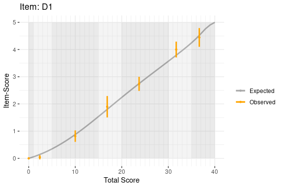

```r
CICCplot(fit, lower.groups = c(1, 5, 15, 20, 30, 35))
```

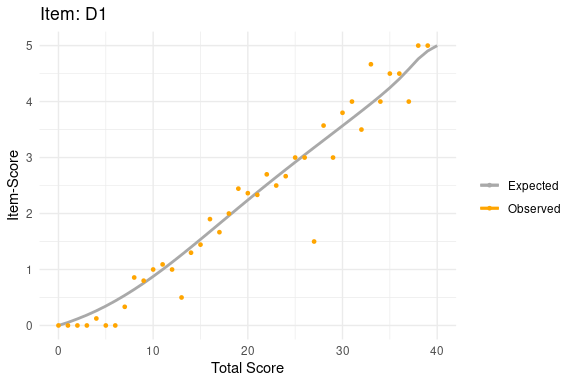

```r
CICCplot(fit, error.bar = FALSE)
```

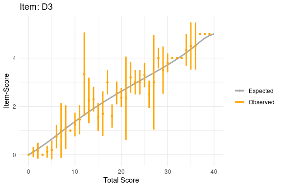

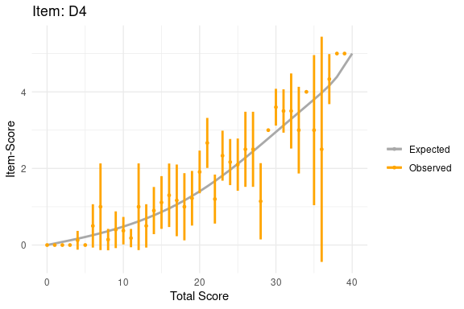

```r
CICCplot(fit, which.item = c(3, 4))
```

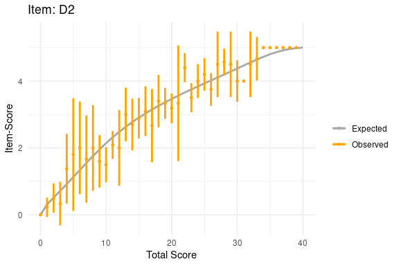

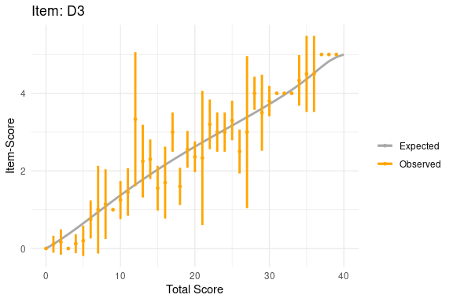

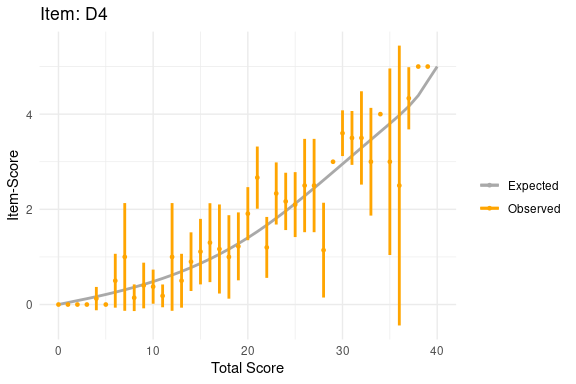

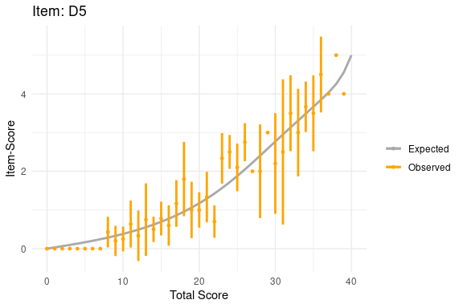

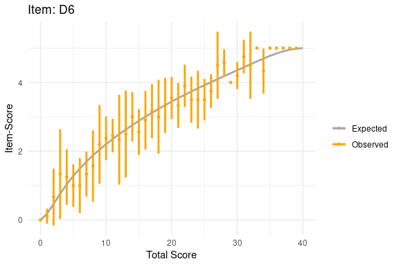

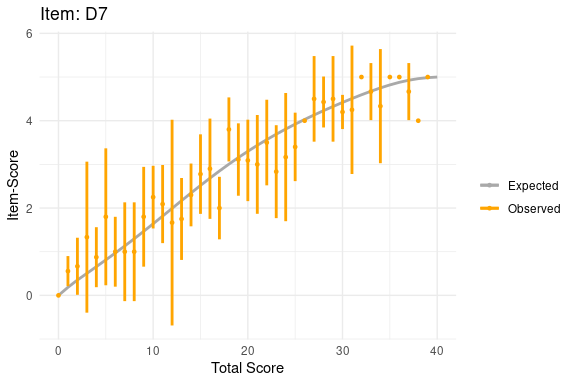

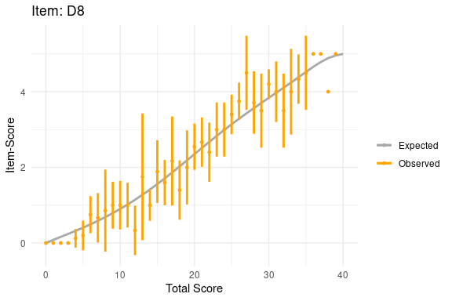

```r
CICCplot(fit, which.item = "all")
```

[output not shown]

Construc CICC plot for all items and grid the items in two columns

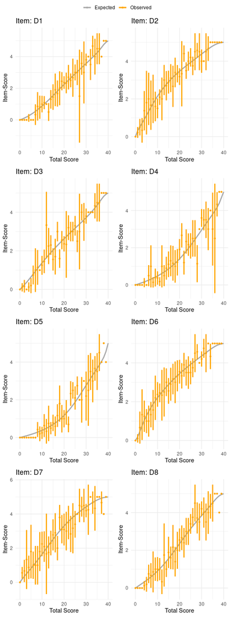

```r
CICCplot(model = fit, which.item = "all", grid.items = TRUE, common.legend = TRUE,
    ncol = 2, nrow = 4)
```

Construct CICC plot for items 1 and 2

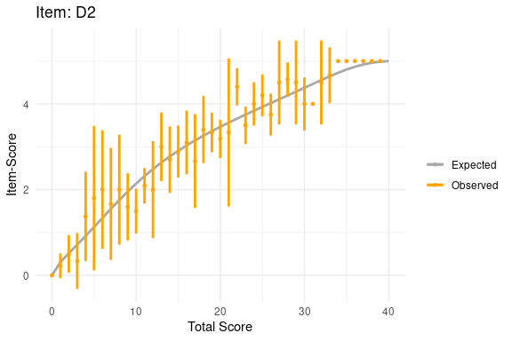

```r
p <- CICCplot(model = fit, which.item = c(1, 2))
p
```

[output not shown]

## Working with `ggplot2`

Default theme for `ggplot2`

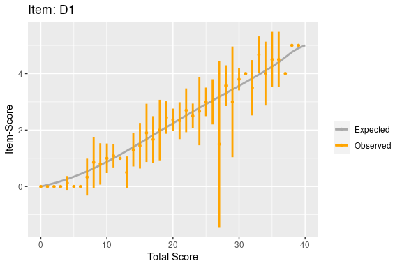

```r
theme_set(theme_gray())
CICCplot(fit)
```

```r
theme_set(theme_minimal())
```

```r
ciccobj <- CICCplot(fit)[[1]]
```

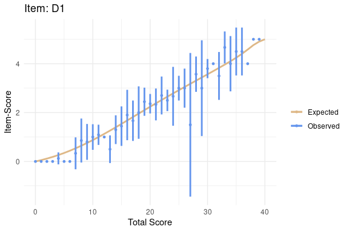

```r
ciccobj + scale_colour_manual(values = c("burlywood", "cornflowerblue"))
```

Change colours and x axis limits

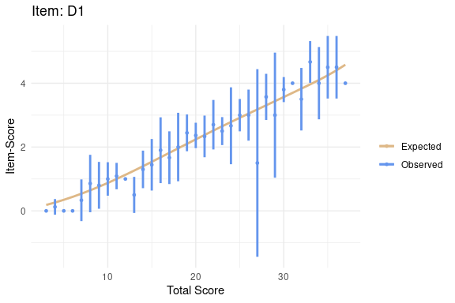

```r
ciccobj + scale_colour_manual(values = c("burlywood", "cornflowerblue")) + xlim(c(3,
    37))
```

Change y axis limits

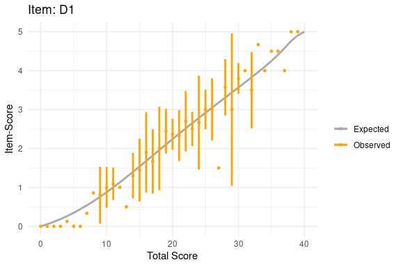

```r
ciccobj + ylim(c(0, 5))
```

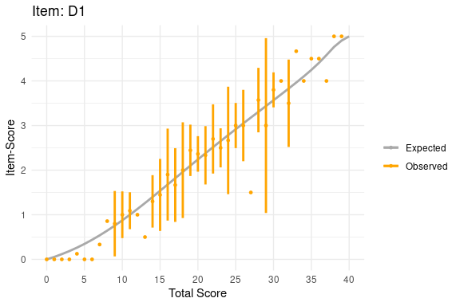

```r
ciccobj + scale_x_continuous(breaks = seq(0, 40, 5), minor_breaks = NULL) + scale_y_continuous(breaks = 0:5,
    minor_breaks = NULL) + ylim(c(0, 5))
```

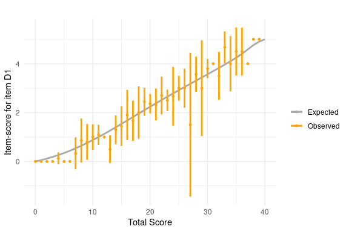

```r
ciccobj + ylab("Item-score for item D1") + ggtitle("")
```

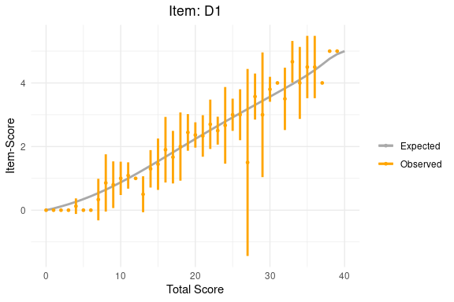

```r
ciccobj + theme(plot.title = element_text(hjust = 0.5))
```